# Extract Gene Partners and Analyze Pairings

## Getting Data

The data is found on the Catalogue of Somatic Mutations in Cancer (COSMIC) website here:

> cancer.sanger.ac.uk/cancergenome/projects/cosmic/download.

The particular file is under the “Complete Fusion Export” tab. The data is described as:

> All gene fusion mutation data from the current release in a tab seperated file (CosmicFusionExport)

Once the data has been downloaded and uncompressed, the file you get is in a tab-separated format but R works better in comma-separated formatted files. I have taken the file into vim to quickly change the `.tsv` file into a `.csv` file with the following command: `:%s/\t/,/g`. The command will remove the tabs (denoted with `\t`) and replace the with commas (denoted with the comma symbol, “,”).

## Load Fusion Data

This analysis is meant to extract the gene pairings from the cosmicFusion data frame. Here is a snipet of the raw data:

```r
# change the name of the file as necessary
cosmicFusion <- read.csv("../data/CosmicFusionExport_v69_310514.csv",
                         header=TRUE,
                         row.names=NULL)

head(cosmicFusion) # see a sample of what the data looks like
```

```
##   row.names id_sample Sample.name Primary.site Site.subtype
## 1   1000017   1000017     thyroid           NS    carcinoma
## 2   1000017   1000017     thyroid           NS    carcinoma
## 3   1000017   1000017     thyroid           NS    carcinoma
## 4   1000018   1000018     thyroid           NS    carcinoma
## 5   1027264   1027264     thyroid           NS    carcinoma
## 6   1027265   1027265     thyroid           NS    carcinoma
##     Primary.histology Histology.subtype
## 1 papillary_carcinoma                NA
## 2 papillary_carcinoma              1271
## 3 papillary_carcinoma              1272
## 4 papillary_carcinoma                NA
## 5 papillary_carcinoma                NA
## 6 papillary_carcinoma              1216
##                                                         Fusion.ID
## 1
## 2 CCDC6{ENST00000263102}:r.1_535_RET{ENST00000355710}:r.2369_5659
## 3 CCDC6{ENST00000263102}:r.1_535_RET{ENST00000355710}:r.2369_5659
## 4
## 5
## 6                    PAX8{NM_003466.2}:r.?_PPARG{NM_015869.2}:r.?
##    Fusion.Description
## 1
## 2       Observed mRNA
## 3 Inferred Breakpoint
## 4
## 5
## 6 Inferred Breakpoint
```

```r
dim(cosmicFusion) # see how large the dataset
```

```
## [1] 53519     9
```

Under “Fusion_Descriptions,” there contains information about the directionality of the gene fusion. The letters before each set of brackets are the genes representing the 5’ and 3’ genes in the fusion. The 5’ gene is first and the 3’ gene is second.

**NOTE: There was a error in the original data file imported in Line 11620. There was a missing left bracket so my separation algorithm implemented later on failed for that line.**

## Focus on Description Data

We know that we need to focus on the “Fusion_Description” and “Reason” columns so we shall save it in another data frame.

```r
fusionDescription <- cosmicFusion[,8:9] # save Descriptions and Reason
head(fusionDescription) # show beginning of new data frame
```

```
##                                                         Fusion.ID
## 1
## 2 CCDC6{ENST00000263102}:r.1_535_RET{ENST00000355710}:r.2369_5659
## 3 CCDC6{ENST00000263102}:r.1_535_RET{ENST00000355710}:r.2369_5659
## 4
## 5
## 6                    PAX8{NM_003466.2}:r.?_PPARG{NM_015869.2}:r.?
##    Fusion.Description
## 1
## 2       Observed mRNA
## 3 Inferred Breakpoint
## 4
## 5
## 6 Inferred Breakpoint
```

## Remove Empty Cells

There are many empty spaces in between the data we want. Let us remove these spaces and keep only the cells with information in them.

```r
dim(fusionDescription)[1] # number of fusions at this step
```

```
## [1] 53519
```

```r
fusionDescription <- fusionDescription[fusionDescription[,1] != "", ] # remove spaces
Description <- as.character(fusionDescription[ ,1]) # to change descriptions
Reason <- as.character(fusionDescription[ ,2]) # to change reasons
rawFusions <- cbind(Description, Reason) # put them together
rawFusions <- rawFusions[ ,1] # keep just the descriptions
head(rawFusions)
```

```
## [1] "CCDC6{ENST00000263102}:r.1_535_RET{ENST00000355710}:r.2369_5659"
## [2] "CCDC6{ENST00000263102}:r.1_535_RET{ENST00000355710}:r.2369_5659"
## [3] "PAX8{NM_003466.2}:r.?_PPARG{NM_015869.2}:r.?"
## [4] "TMPRSS2{ENST00000332149}:r.1_150_ERG{ENST00000442448}:r.530_5034"
## [5] "TMPRSS2{ENST00000332149}:r.1_79_ERG{ENST00000442448}:r.530_5034"
## [6] "TMPRSS2{ENST00000332149}:r.1_150_ERG{ENST00000442448}:r.530_5034"
```

```r
length(rawFusions) # number of fusions left
```

```
## [1] 18907
```

## Note on Inferred Breakpoint/Observed mRNA

In the data source, there are two categories for the genes: inferred breakpoint or observed mRNA. The difference between the two are highlighted on the COSMIC website.

Inferred breakpoints are when the literature reports more than one transcript per sample, implying that there are multiple variants. The observed mRNA are determined from experimental measures.

Because they are still valid variants of the sequences, we have decided to keep them in the analysis.

Source: http://cancer.sanger.ac.uk/cosmic/help/fusion/overview

## Plan to Convert Single-line Elements to Data Frame

Now that we have only the elements we need, we can proceed in separating the relavent data in the array we created.

The general structure of the description is:

> 5GENE{ID}:r.BEGIN_END_3GENE{ID}:r.BEGIN_END

There are also cases where there is no information of where the breakpoints are, so we need to take those into account as well. Those will look like this:

> 5GENE{ID}:r.?_3GENE{ID}:r.?

We will not consider those cases with unknown breakpoints, inverted genes, insertions, or complex/multiple fusion partners.

To separate the string, we need to consider multiple characters:

- keep the 5’ and 3’ gene name
- remove ID between the both sets of brackets
- keep the breakpoints for 5’ and 3’ gene
- ignore inverted genes (there is an ‘o’ character in front of the 3’ gene)
- ignore the complex gene fusions with multiple partners
- ignore breakpoints in intron regions (marked with ‘+’ and ‘-’ signs)
- ignore fusions with unknown breakpoints (labeled with a question mark in the breakpoint syntax)

## Remove Duplicates

```r
# remove duplicates before doing anything else
head(rawFusions)
```

```
## [1] "CCDC6{ENST00000263102}:r.1_535_RET{ENST00000355710}:r.2369_5659"
## [2] "CCDC6{ENST00000263102}:r.1_535_RET{ENST00000355710}:r.2369_5659"
## [3] "PAX8{NM_003466.2}:r.?_PPARG{NM_015869.2}:r.?"
## [4] "TMPRSS2{ENST00000332149}:r.1_150_ERG{ENST00000442448}:r.530_5034"
## [5] "TMPRSS2{ENST00000332149}:r.1_79_ERG{ENST00000442448}:r.530_5034"
## [6] "TMPRSS2{ENST00000332149}:r.1_150_ERG{ENST00000442448}:r.530_5034"
```

```r
length(rawFusions)
```

```
## [1] 18907
```

```r
uniqueFusions <- rawFusions[!duplicated(rawFusions)]
head(uniqueFusions)
```

```
## [1] "CCDC6{ENST00000263102}:r.1_535_RET{ENST00000355710}:r.2369_5659"
## [2] "PAX8{NM_003466.2}:r.?_PPARG{NM_015869.2}:r.?"
## [3] "TMPRSS2{ENST00000332149}:r.1_150_ERG{ENST00000442448}:r.530_5034"
## [4] "TMPRSS2{ENST00000332149}:r.1_79_ERG{ENST00000442448}:r.530_5034"
## [5] "TMPRSS2{ENST00000332149}:r.1_79_ERG{ENST00000442448}:r.312_5034"
## [6] "TMPRSS2{ENST00000332149}:r.1_79_ERG{ENST00000442448}:r.124_5034"
```

```r
length(uniqueFusions) # number of fusions now
```

```
## [1] 874
```

## Remove Unknown Breakpoints

```r
uniqueKnownBreakpointFusions <- grep("\\?",
                                    uniqueFusions,
                                    value=TRUE,
                                    invert=TRUE)
head(uniqueKnownBreakpointFusions)
```

```
## [1] "CCDC6{ENST00000263102}:r.1_535_RET{ENST00000355710}:r.2369_5659"
## [2] "TMPRSS2{ENST00000332149}:r.1_150_ERG{ENST00000442448}:r.530_5034"
## [3] "TMPRSS2{ENST00000332149}:r.1_79_ERG{ENST00000442448}:r.530_5034"
## [4] "TMPRSS2{ENST00000332149}:r.1_79_ERG{ENST00000442448}:r.312_5034"
## [5] "TMPRSS2{ENST00000332149}:r.1_79_ERG{ENST00000442448}:r.124_5034"
## [6] "TMPRSS2{ENST00000332149}:r.1_150_ERG{ENST00000442448}:r.124_5034"
```

```r
length(uniqueKnownBreakpointFusions) # number of fusions now
```

```
## [1] 801
```

## Remove Insertions

There are some gene fusions that have inserted genetic sequences. Let us remove them for simplicity.

We have not separated the fusions between simple and complex so this subset of the data with insertions will contain both simple and complex fusions.

```r
# save insertions in another matrix
insertions <- grep("_ins",
                   uniqueKnownBreakpointFusions,
                   value=TRUE)
head(insertions) # sample of insertions
```

```
## [1] "SS18{ENST00000415083}:r.1_1286_insGAGUGG_SSX1{ENST00000376919}:r.383_1298"
## [2] "SS18{ENST00000415083}:r.1_1286_insGAGUGG_SSX1{ENST00000376919}:r.321_1298"
## [3] "SS18{ENST00000415083}:r.1_1286_insAT_SSX2{NM_003147.4}:r.439-1995_439-1941_SSX2{NM_003147.4}:r.439_1466"
## [4] "SS18{ENST00000415083}:r.1_1286_insAU_SSX2{NM_003147.4}:r.439-1995_1448"
## [5] "EWSR1{ENST00000397938}:r.1_1293_insCCAACC_WT1{NM_024426.2}:r.1242_2825"
## [6] "EWSR1{ENST00000397938}:r.1_1293_EWSR1{ENST00000397938}:r.1293+1627_1293+1656_insU_SP3{ENST00000310015}:r.2389_6359"
```

```r
length(insertions) # how many insertions
```

```
## [1] 47
```

```r
# remove insertions
uniqueKnownBreakpointFusions <- grep("_ins",
                                     uniqueKnownBreakpointFusions,
                                     value=TRUE,
                                     invert=TRUE) # keep non-insertions
head(uniqueKnownBreakpointFusions)
```

```
## [1] "CCDC6{ENST00000263102}:r.1_535_RET{ENST00000355710}:r.2369_5659"
## [2] "TMPRSS2{ENST00000332149}:r.1_150_ERG{ENST00000442448}:r.530_5034"
## [3] "TMPRSS2{ENST00000332149}:r.1_79_ERG{ENST00000442448}:r.530_5034"
## [4] "TMPRSS2{ENST00000332149}:r.1_79_ERG{ENST00000442448}:r.312_5034"
## [5] "TMPRSS2{ENST00000332149}:r.1_79_ERG{ENST00000442448}:r.124_5034"
## [6] "TMPRSS2{ENST00000332149}:r.1_150_ERG{ENST00000442448}:r.124_5034"
```

```r
length(uniqueKnownBreakpointFusions) # number of fusions now
```

```
## [1] 754
```

## Remove Intronic Breakpoints

We will remove the fusions with breakpoints with upstream and downstream breakpoints, as indicated with `+` and `-` signs. This will simplify parsing. In the future, these can be added back in to get a more complete picture, but for now we can remove them.

```r
uniqueKnownBreakpointFusions <- grep("\\+",
               uniqueKnownBreakpointFusions,
               value = TRUE,
               invert = TRUE)
uniqueKnownBreakpointFusions <- grep("\\-",
                    uniqueKnownBreakpointFusions,
                    value = TRUE,
                    invert = TRUE)
length(uniqueKnownBreakpointFusions)
```

```
## [1] 561
```

## Remove Inverted Fusions

There are some fusions that have inverted elements in them. We wish to ignore those cases for now. These fusions with inverted elements are labeled with an “o” before the gene name, like before the second gene here:

> FUS{ENST00000254108}:r.1_628_oCREB3L2{ENST00000330387}:r.972_984_CREB3L2{ENST00000330387}:r.1006_7412

```r
uniqueKnownBreakpointFusions <- grep("_o",
                                     uniqueKnownBreakpointFusions,
                                     value = TRUE,
                                     invert = TRUE)
length(uniqueKnownBreakpointFusions)
```

```
## [1] 559
```

## Discern Complex Gene Fusions from Simple Ones

The fusions we want are the ones involving pairs of genes. To make the analysis easier, we will put the fusions into two categories: complex and simple. The simple ones have just a pair of genes and nothing too complicated in the syntax. The complicated case might involve only two genes in the fusion but has been combined more than once. We will consider these but right now, we will complete one step at a time, namely separate the simple from the complicated cases.

```r
library("stringr") # load appropriate package first

allSizes <- str_locate_all(uniqueKnownBreakpointFusions, ":")
n <- length(allSizes)
nArray <- array(data = NA, dim = n) # T/F array

for (i in 1:n) { # loop through all elements
    if (dim(allSizes[[i]])[1] > 2) { # if gene fusion is complex
        nArray[i] <- FALSE # don't include it
        next
    } else {
        nArray[i] <- TRUE # include it otherwise
    }
}
# simple cases
simpleUniqueFusions <- uniqueKnownBreakpointFusions[nArray]

# complex cases
complexUniqueFusions <- uniqueKnownBreakpointFusions[!nArray]

# summary of simple
head(simpleUniqueFusions)
```

```
## [1] "CCDC6{ENST00000263102}:r.1_535_RET{ENST00000355710}:r.2369_5659"
## [2] "TMPRSS2{ENST00000332149}:r.1_150_ERG{ENST00000442448}:r.530_5034"
## [3] "TMPRSS2{ENST00000332149}:r.1_79_ERG{ENST00000442448}:r.530_5034"
## [4] "TMPRSS2{ENST00000332149}:r.1_79_ERG{ENST00000442448}:r.312_5034"
## [5] "TMPRSS2{ENST00000332149}:r.1_79_ERG{ENST00000442448}:r.124_5034"
## [6] "TMPRSS2{ENST00000332149}:r.1_150_ERG{ENST00000442448}:r.124_5034"
```

```r
length(simpleUniqueFusions) # the number of simple gene fusions so far
```

```
## [1] 527
```

```r
# summary of complex
head(complexUniqueFusions)
```

```
## [1] "TMPRSS2{ENST00000332149}:r.1_150_ERG{AY204740.1}:r.226_320_ERG{ENST00000442448}:r.312_5034"
## [2] "EWSR1{ENST00000397938}:r.1_1293_EWSR1{ENST00000397938}:r.1332_1364_FLI1{ENST00000429175}:r.854_3051"
## [3] "EWSR1{ENST00000397938}:r.1_1293_EWSR1{ENST00000397938}:r.1332_1364_FLI1{ENST00000429175}:r.1046_3051"
## [4] "TMPRSS2{ENST00000332149}:r.1_79_TMPRSS2{ENST00000332149}:r.374_460_ERG{ENST00000442448}:r.312_5034"
## [5] "TMPRSS2{ENST00000332149}:r.1_79_TMPRSS2{ENST00000332149}:r.374_460_ERG{ENST00000442448}:r.530_5034"
## [6] "EWSR1{ENST00000397938}:r.1_732_EWSR1{ENST00000397938}:r.901_1112_WT1{NM_024426.2}:r.1242_2825"
```

```r
length(complexUniqueFusions)
```

```
## [1] 32
```

## Separate Simple Elements

> 5’ gene | ID | 5’ start | 5’ end | 3’ gene | ID | 3’ start | 3’ end

The start and end numbers are the breakpoints. At the same time, we want to preserve the Ensembl ID numbers for future use.

```r
#  make empty matrix to put new data into
columns <- 8 # number of columns based on the syntax above
rows <- length(simpleUniqueFusions) # number of fusions we're working with
newDescription <- matrix(ncol=columns, nrow=rows) # create matrix we will us

# separate string out using substitution
for (i in 1: rows) {
    pattern <- "(.+){(.+)}:r.([0-9]+)_([0-9]+)_(.+){(.+)}:r.([0-9]+)_([0-9]+)"
    newDescription[i,1] <- sub(pattern,
            "\\1", # want the first set of parentheses
            simpleUniqueFusions[i], # the string to use
            perl = TRUE # use Perl regex
        )
    newDescription[i,2] <- sub(pattern,
            "\\2", # want the second set of parentheses
            simpleUniqueFusions[i], # the string to use
            perl = TRUE # use Perl regex
        )
    newDescription[i,3] <- sub(pattern,
            "\\3", # want the third set of parentheses
            simpleUniqueFusions[i], # the string to use
            perl = TRUE # use Perl regex
        )
    newDescription[i,4] <- sub(pattern,
            "\\4", # want the fourth set of parentheses
            simpleUniqueFusions[i], # the string to use
            perl = TRUE # use Perl regex
        )
    newDescription[i,5] <- sub(pattern,
            "\\5", # want the fifth set of parentheses
            simpleUniqueFusions[i], # the string to use
            perl = TRUE # use Perl regex
        )
    newDescription[i,6] <- sub(pattern,
            "\\6", # want the sixth set of parentheses
            simpleUniqueFusions[i], # the string to use
            perl = TRUE # use Perl regex
        )
    newDescription[i,7] <- sub(pattern,
            "\\7", # want the seventh set of parentheses
            simpleUniqueFusions[i], # the string to use
            perl = TRUE # use Perl regex
        )
    newDescription[i,8] <- sub(pattern,
            "\\8", # want the eighth set of parentheses
            simpleUniqueFusions[i], # the string to use
            perl = TRUE # use Perl regex
        )
}

head(newDescription) # sample of the fusions
```

```
##      [,1]      [,2]              [,3] [,4]  [,5]  [,6]              [,7]
## [1,] "CCDC6"   "ENST00000263102" "1"  "535" "RET" "ENST00000355710" "2369"
## [2,] "TMPRSS2" "ENST00000332149" "1"  "150" "ERG" "ENST00000442448" "530"
## [3,] "TMPRSS2" "ENST00000332149" "1"  "79"  "ERG" "ENST00000442448" "530"
## [4,] "TMPRSS2" "ENST00000332149" "1"  "79"  "ERG" "ENST00000442448" "312"
## [5,] "TMPRSS2" "ENST00000332149" "1"  "79"  "ERG" "ENST00000442448" "124"
## [6,] "TMPRSS2" "ENST00000332149" "1"  "150" "ERG" "ENST00000442448" "124"
##      [,8]
## [1,] "5659"
## [2,] "5034"
## [3,] "5034"
## [4,] "5034"
## [5,] "5034"
## [6,] "5034"
```

```r
dim(newDescription)[1] # how many fusions do we have
```

```
## [1] 527
```

```r
# data exploration
write.table(newDescription, "../results/newDescription.txt")
```

## Unique Simple Gene Pairings

We have all the unique gene fusions but we do not have all the unique gene fusion pairings. Let us see how many unique gene pairings we have.

```r
simplePairings <- cbind(newDescription[, 1], # 5' gene
                        newDescription[, 5]) # 3' gene
uniquePairings <- simplePairings[!duplicated(simplePairings), ]
head(uniquePairings) # sample what we have
```

```
##      [,1]      [,2]
## [1,] "CCDC6"   "RET"
## [2,] "TMPRSS2" "ERG"
## [3,] "TMPRSS2" "ETV1"
## [4,] "SS18"    "SSX2"
## [5,] "SS18"    "SSX1"
## [6,] "SS18"    "SSX4"
```

```r
dim(uniquePairings)[1] # number of simple unique gene fusion pairs
```

```
## [1] 225
```

## Dealing with Complex Cases

Here we will deal with the complex cases that were saved from earlier. Here we will only consider pairs of complex gene fusions. The plan is to parse through each fusion and count the number of genes in each case. If there are more than two genes in a single gene fusion, then it will not be counted.

Because of how the string processing function in R works, I will still need to separate the complex gene fusions a little bit.

## Count Number of Genes in Complex Cases

The way the string functions work in R as of now force me to count the number of genes in the fusion before moving on to see if there exist a pairing or a group of genes.

```r
length(complexUniqueFusions) # need this number to double check out totals
```

```
## [1] 32
```

```r
allSizesAgain <- str_locate_all(complexUniqueFusions, ":")
n <- length(allSizesAgain)
nArray <- array(data = NA, dim = n) # T/F array

for (i in 1:n) { # loop through all elements
    if (dim(allSizesAgain[[i]])[1] == 4) { # if gene fusion has more than 3 parts
        nArray[i] <- FALSE # reclassify it
        next
    }
    if (dim(allSizesAgain[[i]])[1] == 3) {
        nArray[i] <- TRUE # know that it comprises of three groups
    }
}

# fusion with three parts
threeFusionsRaw <- complexUniqueFusions[nArray] # complex fusions w/ 3 parts
length(threeFusionsRaw) # number of fusions with three parts
```

```
## [1] 31
```

```r
head(threeFusionsRaw) # a peek at the data
```

```
## [1] "TMPRSS2{ENST00000332149}:r.1_150_ERG{AY204740.1}:r.226_320_ERG{ENST00000442448}:r.312_5034"
## [2] "EWSR1{ENST00000397938}:r.1_1293_EWSR1{ENST00000397938}:r.1332_1364_FLI1{ENST00000429175}:r.854_3051"
## [3] "EWSR1{ENST00000397938}:r.1_1293_EWSR1{ENST00000397938}:r.1332_1364_FLI1{ENST00000429175}:r.1046_3051"
## [4] "TMPRSS2{ENST00000332149}:r.1_79_TMPRSS2{ENST00000332149}:r.374_460_ERG{ENST00000442448}:r.312_5034"
## [5] "TMPRSS2{ENST00000332149}:r.1_79_TMPRSS2{ENST00000332149}:r.374_460_ERG{ENST00000442448}:r.530_5034"
## [6] "EWSR1{ENST00000397938}:r.1_732_EWSR1{ENST00000397938}:r.901_1112_WT1{NM_024426.2}:r.1242_2825"
```

```r
# fusion with more than three parts
fourFusions <- complexUniqueFusions[!nArray] # complex fusions w/ >3 parts
length(fourFusions) # number of fusions with four parts
```

```
## [1] 1
```

```r
head(fourFusions) # sampling of the fusions with four parts
```

```
## [1] "MYB{ENST00000341911}:r.1_1402_MYB{ENST00000341911}:r.1766_2368_NFIB{ENST00000397581}:r.2254_2392_NFIB{ENST00000397581}:r.2420_3318"
```

After separating the dataset into fusions with three parts and another only with four parts, we still have the correct total. Thus, there are no gene fusions in our dataset that have more than four parts together we have to worry about.

## Remove Breakpoints with Parentheses

Upon looking at some of the fusions with three components, there are some with parentheses in the breakpoint regions. I cannot find out what this information means yet. I can only guess that this means that those breakpoints are not certain. Some of them are ranges:

> EWSR1{ENST00000397938}:r.1_(546_732)*EWSR1{ENST00000397938}:r.1294*1331_WT1{NM_024426.2}:r.1242_2825.

Others are just enclosed in parentheses:

> FUS{ENST00000254108}:r.1_(608)*FUS{ENST00000254108}:r.(819)*937_DDIT3{ENST00000547303}:r.76_872.

```r
nArray <- array(data = NA, dim = length(threeFusionsRaw)) # get T/F array
parenFusions <- grep("\\(", threeFusionsRaw, value=TRUE) # save paren fusions
head(parenFusions) # let's take a look
```

```
## [1] "EWSR1{ENST00000397938}:r.1_(546_732)_EWSR1{ENST00000397938}:r.1294_1331_WT1{NM_024426.2}:r.1242_2825"
## [2] "EWSR1{ENST00000397938}:r.1_(733_900)_EWSR1{ENST00000397938}:r.1294_1331_WT1{NM_024426.2}:r.1242_2825"
## [3] "FUS{ENST00000254108}:r.1_(608)_FUS{ENST00000254108}:r.(819)_937_DDIT3{ENST00000547303}:r.76_872"
## [4] "FUS{ENST00000254108}:r.1_(608)_FUS{ENST00000254108}:r.(819)_904_DDIT3{ENST00000547303}:r.76_872"
```

```r
length(parenFusions) # how many parentheses fusions do we have
```

```
## [1] 4
```

Now we will save the normal fusions without the parerntheses.

```r
threeFusionsRaw <- grep("\\(", threeFusionsRaw, value=TRUE, invert=TRUE)
head(threeFusionsRaw) # see if the data looks right
```

```
## [1] "TMPRSS2{ENST00000332149}:r.1_150_ERG{AY204740.1}:r.226_320_ERG{ENST00000442448}:r.312_5034"
## [2] "EWSR1{ENST00000397938}:r.1_1293_EWSR1{ENST00000397938}:r.1332_1364_FLI1{ENST00000429175}:r.854_3051"
## [3] "EWSR1{ENST00000397938}:r.1_1293_EWSR1{ENST00000397938}:r.1332_1364_FLI1{ENST00000429175}:r.1046_3051"
## [4] "TMPRSS2{ENST00000332149}:r.1_79_TMPRSS2{ENST00000332149}:r.374_460_ERG{ENST00000442448}:r.312_5034"
## [5] "TMPRSS2{ENST00000332149}:r.1_79_TMPRSS2{ENST00000332149}:r.374_460_ERG{ENST00000442448}:r.530_5034"
## [6] "EWSR1{ENST00000397938}:r.1_732_EWSR1{ENST00000397938}:r.901_1112_WT1{NM_024426.2}:r.1242_2825"
```

```r
length(threeFusionsRaw) # how many do we have left
```

```
## [1] 27
```

## Separate Complex Gene Fusion Strings and Filter Pairs with Three Genes

```r
head(threeFusionsRaw) # see a bit of the data
```

```
## [1] "TMPRSS2{ENST00000332149}:r.1_150_ERG{AY204740.1}:r.226_320_ERG{ENST00000442448}:r.312_5034"
## [2] "EWSR1{ENST00000397938}:r.1_1293_EWSR1{ENST00000397938}:r.1332_1364_FLI1{ENST00000429175}:r.854_3051"
## [3] "EWSR1{ENST00000397938}:r.1_1293_EWSR1{ENST00000397938}:r.1332_1364_FLI1{ENST00000429175}:r.1046_3051"
## [4] "TMPRSS2{ENST00000332149}:r.1_79_TMPRSS2{ENST00000332149}:r.374_460_ERG{ENST00000442448}:r.312_5034"
## [5] "TMPRSS2{ENST00000332149}:r.1_79_TMPRSS2{ENST00000332149}:r.374_460_ERG{ENST00000442448}:r.530_5034"
## [6] "EWSR1{ENST00000397938}:r.1_732_EWSR1{ENST00000397938}:r.901_1112_WT1{NM_024426.2}:r.1242_2825"
```

```r
length(threeFusionsRaw) # see how many three gene'd fusions we have
```

```
## [1] 27
```

```r
nArray <- array(data = NA, dim = length(threeFusionsRaw)) # TRUE/FALSE array
pairsMatrix <- c(); # empty

otherPairs <- c();
for (i in 1:length(threeFusionsRaw)) {
    pattern <- "(.+){(.+)}:r\\.([0-9]+)_([0-9]+)_(.+){(.+)}:r\\.([0-9]+)_([0-9]+)_.+{.+}:r\\.[0-9]+_[0-9]+"

    # first gene information
    first <- sub(pattern,
            "\\1", # want the first set of parentheses
            threeFusionsRaw[i], # the string to use
            perl = TRUE # use Perl regex
        )
    firstID <- sub(pattern, "\\2", threeFusionsRaw[i], perl = TRUE)
    firstStart <- sub(pattern, "\\3", threeFusionsRaw[i], perl = TRUE)
    firstEnd <- sub(pattern, "\\4", threeFusionsRaw[i], perl = TRUE)

    # second gene information
    second <- sub(pattern,
            "\\5", # want the second set of parentheses
            threeFusionsRaw[i], # the string to use
            perl = TRUE # use Perl regex
        )
    secondID <- sub(pattern, "\\6", threeFusionsRaw[i], perl = TRUE)
    secondStart <- sub(pattern, "\\7", threeFusionsRaw[i], perl = TRUE)
    secondEnd <- sub(pattern, "\\8", threeFusionsRaw[i], perl = TRUE)

    # regex does not allow more than nine groups, so I gotta redefine the
    # pattern so that I can extract the rest of the information
    pattern <- ".+{.+}:r\\.[0-9]+_[0-9]+_.+{.+}:r\\.[0-9]+_[0-9]+_(.+){(.+)}:r\\.([0-9]+)_([0-9]+)"

    # three gene information
    third <- sub(pattern,
            "\\1", # want the third set of parentheses
            threeFusionsRaw[i], # the string to use
            perl = TRUE # use Perl regex
        )
    thirdID <- sub(pattern, "\\2", threeFusionsRaw[i], perl = TRUE)
    thirdStart <- sub(pattern, "\\3", threeFusionsRaw[i], perl = TRUE)
    thirdEnd <- sub(pattern, "\\4", threeFusionsRaw[i], perl = TRUE)

    # put information together
    otherPairs <- rbind(otherPairs,
                        c(first, firstID, firstStart, firstEnd,
                          second, secondID, secondStart, secondEnd,
                          third, thirdID, thirdStart, thirdEnd),
                        deparse.level=0)

    # figure out if pairing or not
    if (sum(duplicated(c(first, second, third))) == 1) {
        nArray[i] <- TRUE # keep
        allThree <- c(first, second, third) # put all three together
        uniqueThreePairs <- allThree[!duplicated(allThree)] # find unique pair

        # make pairs matrix
        pairsMatrix <- rbind(pairsMatrix,
                             uniqueThreePairs,
                             deparse.level = 0)
    } else {
        nArray[i] <- FALSE # do not keep
    }
}

# only keep pairs
otherPairs <- otherPairs[nArray,]
head(otherPairs) # did we filter and separate correctly
```

```
##      [,1]      [,2]              [,3] [,4]   [,5]      [,6]
## [1,] "TMPRSS2" "ENST00000332149" "1"  "150"  "ERG"     "AY204740.1"
## [2,] "EWSR1"   "ENST00000397938" "1"  "1293" "EWSR1"   "ENST00000397938"
## [3,] "EWSR1"   "ENST00000397938" "1"  "1293" "EWSR1"   "ENST00000397938"
## [4,] "TMPRSS2" "ENST00000332149" "1"  "79"   "TMPRSS2" "ENST00000332149"
## [5,] "TMPRSS2" "ENST00000332149" "1"  "79"   "TMPRSS2" "ENST00000332149"
## [6,] "EWSR1"   "ENST00000397938" "1"  "732"  "EWSR1"   "ENST00000397938"
##      [,7]   [,8]   [,9]   [,10]             [,11]  [,12]
## [1,] "226"  "320"  "ERG"  "ENST00000442448" "312"  "5034"
## [2,] "1332" "1364" "FLI1" "ENST00000429175" "854"  "3051"
## [3,] "1332" "1364" "FLI1" "ENST00000429175" "1046" "3051"
## [4,] "374"  "460"  "ERG"  "ENST00000442448" "312"  "5034"
## [5,] "374"  "460"  "ERG"  "ENST00000442448" "530"  "5034"
## [6,] "901"  "1112" "WT1"  "NM_024426.2"     "1242" "2825"
```

```r
# get gene pairings
head(pairsMatrix)
```

```
##      [,1]      [,2]
## [1,] "TMPRSS2" "ERG"
## [2,] "EWSR1"   "FLI1"
## [3,] "EWSR1"   "FLI1"
## [4,] "TMPRSS2" "ERG"
## [5,] "TMPRSS2" "ERG"
## [6,] "EWSR1"   "WT1"
```

```r
dim(pairsMatrix)[1] # number of three part fusions
```

```
## [1] 27
```

## Separate Complex Gene Fusion Strings and Filter Pairs with Four Genes

There is only one gene fusion that has made it thus far in the filtering so we can separate the string personally on this one string.

If the above filtering process changes, this part may need to be revised to accommodate the number of strings to parse.

```r
initSeparate <- str_extract_all(string = fourFusions,
                               pattern = "[^\\.:\\{r\\_\\}]+")
initSeparate <- initSeparate[[1]]
initSeparate # see what we got
```

```
##  [1] "MYB"             "ENST00000341911" "1"
##  [4] "1402"            "MYB"             "ENST00000341911"
##  [7] "1766"            "2368"            "NFIB"
## [10] "ENST00000397581" "2254"            "2392"
## [13] "NFIB"            "ENST00000397581" "2420"
## [16] "3318"
```

```r
fourPair <- c(initSeparate[1], initSeparate[9]) # the two genes in the fusion
pairsMatrix <- rbind(pairsMatrix,
                     fourPair)

# check data
tail(pairsMatrix) # note the addition to the end of the pairs matrix
```

```
##          [,1]    [,2]
##          "MYB"   "NFIB"
##          "PAX8"  "PPARG"
##          "PAX8"  "PPARG"
##          "EWSR1" "FLI1"
##          "ACTB"  "GLI1"
## fourPair "MYB"   "NFIB"
```

```r
dim(pairsMatrix)[1] # number of complex pairs
```

```
## [1] 28
```

## Complete Unique Pairings

Here we need to put all three datasets back together and then run the uniqueness algorithm on it to find the complete list of unique gene pairings in the gene fusions in our dataset.

```r
allPairsRaw <- rbind(uniquePairings,
                  pairsMatrix,
                  deparse.level = 0 # no labels
                  )
allUniquePairs <- allPairsRaw[!duplicated(allPairsRaw), ]
head(allUniquePairs) # sample unique pairs data
```

```
##  [,1]      [,2]
##  "CCDC6"   "RET"
##  "TMPRSS2" "ERG"
##  "TMPRSS2" "ETV1"
##  "SS18"    "SSX2"
##  "SS18"    "SSX1"
##  "SS18"    "SSX4"
```

```r
dim(allUniquePairs)[1] # how many unique pairs
```

```
## [1] 225
```

## Load and Discuss Ensembl Genome Dataset

We have decided to stick with the Ensembl genome set to map to the COSMIC data so we can figure out the mechanism for each gene fusion.

Each gene fusion can occur among three different mechanisms:

- a strongly expressed promotor of one gene being fused with a second gene, thus the second gene being expressed more
- a conjoining between the 5’-most end of a gene with the 3’-more end of a second gene
- “the fusion results in the truncation or loss of function of a tumor suppressor gene”

We want to focus on the second case of two functional pieces of genes are fused instead of a gain or loss of function, in the case of the other two choices.

```r
ensemblData <- read.csv(file = "../raw-data/ensembl_GRCh37_2014.08.29.csv",
                        header = TRUE)
head(ensemblData) # the top of the data
```

```
##   Associated_Gene_Name Ensembl_Transcript_ID X5_UTR_Start X5_UTR_End
## 1             SLC25A26       ENST00000566782     66119285   66119659
## 2             SLC25A26       ENST00000566782     66298434   66298786
## 3             SLC25A26       ENST00000566782           NA         NA
## 4             SLC25A26       ENST00000566782           NA         NA
## 5             SLC25A26       ENST00000566782           NA         NA
## 6             SLC25A26       ENST00000566782           NA         NA
##   Exon_Chr_Start_bp Exon_Chr_End_bp X3_UTR_Start X3_UTR_End Strand
## 1          66119285        66119659           NA         NA      1
## 2          66298434        66298819           NA         NA      1
## 3          66314236        66314392           NA         NA      1
## 4          66320895        66321004           NA         NA      1
## 5          66339743        66339847           NA         NA      1
## 6          66341024        66341071           NA         NA      1
##   Exon_Rank_in_Transcript
## 1                       1
## 2                       2
## 3                       3
## 4                       4
## 5                       5
## 6                       6
```

```r
dim(ensemblData)[1] # how many entries we have
```

```
## [1] 1172249
```

Now that we have the data in R, we can mess around with it. What we really need from this dataset is the Ensembl trascript ID (because this is what is in the COSMIC file to uniquely identify each component of the fusion), and the 5’ UTR start and end points.

The COSMIC dataset gives me the breakpoints of the 5’ gene. To figure out the mechanism, I need to get the 5’ breakpoint and compare that to the difference in the 5’ UTR start and end points. If the 5’ breakpoint of the 5’ gene in the fusion is less than the difference in the UTR start and end, then the gene fusion is a strong promoter gene fusion, which we do not want.

## Filter and Save Fusions with Non-Ensembl ID (Two Part Fusions)

Looking at the dataset, we can observe some fusions with non-Ensembl IDs. These IDs are from NCBI. It will be more complicated to take these into account for now so we will filter them out and save them for later use.

Here we will filter and save fusions with two parts. Three and four part fusions will be handled in the proceeding sections.

```r
# filter those with underscores for five prime gene, will fix later
enID <- grep("ENST",
            newDescription[,2],
            invert = FALSE)
nonEnID <- grep("ENST",
                newDescription[,2],
                invert = TRUE)

# save non-Ensembl ID fusions
newDescriptionNonEnID <- newDescription[nonEnID,]
dim(newDescriptionNonEnID)[1] # how many non-Ensembl fusions
```

```
## [1] 14
```

```r
# save Ensembl ID fusions
newDescription <- newDescription[enID,]
dim(newDescription)[1] # how many Ensembl fusions in first gene
```

```
## [1] 513
```

```r
# add in filtered three prime genes as well
enID <- grep("ENST",
             newDescription[,6],
             invert = FALSE)
nonEnID <- grep("ENST",
                newDescription[,6],
                invert = TRUE)

# save non-Ensembl ID fusions
newDescriptionNonEnID <- rbind(newDescriptionNonEnID,
                               newDescription[nonEnID,])
head(newDescriptionNonEnID)
```

```
##      [,1]     [,2]          [,3] [,4]   [,5]     [,6]              [,7]
## [1,] "FBXL18" "NM_024963.2" "1"  "112"  "RNF216" "ENST00000389902" "2721"
## [2,] "HAS2"   "NM_005328.1" "1"  "535"  "PLAG1"  "ENST00000316981" "160"
## [3,] "HAS2"   "NM_005328.1" "1"  "535"  "PLAG1"  "ENST00000316981" "265"
## [4,] "ARID1A" "NM_006015.3" "1"  "1507" "MAST2"  "ENST00000361297" "461"
## [5,] "NUP107" "NM_020401.1" "1"  "123"  "LGR5"   "ENST00000266674" "1382"
## [6,] "PAX8"   "NM_003466.2" "1"  "1355" "PPARG"  "NM_015869.2"     "216"
##      [,8]
## [1,] "3293"
## [2,] "7322"
## [3,] "7322"
## [4,] "5738"
## [5,] "4611"
## [6,] "1854"
```

```r
dim(newDescriptionNonEnID)[1] # how many non-Ensembl fusions
```

```
## [1] 52
```

```r
# save Ensembl ID Fusions
newDescription <- newDescription[enID,]
head(newDescription)
```

```
##      [,1]      [,2]              [,3] [,4]  [,5]  [,6]              [,7]
## [1,] "CCDC6"   "ENST00000263102" "1"  "535" "RET" "ENST00000355710" "2369"
## [2,] "TMPRSS2" "ENST00000332149" "1"  "150" "ERG" "ENST00000442448" "530"
## [3,] "TMPRSS2" "ENST00000332149" "1"  "79"  "ERG" "ENST00000442448" "530"
## [4,] "TMPRSS2" "ENST00000332149" "1"  "79"  "ERG" "ENST00000442448" "312"
## [5,] "TMPRSS2" "ENST00000332149" "1"  "79"  "ERG" "ENST00000442448" "124"
## [6,] "TMPRSS2" "ENST00000332149" "1"  "150" "ERG" "ENST00000442448" "124"
##      [,8]
## [1,] "5659"
## [2,] "5034"
## [3,] "5034"
## [4,] "5034"
## [5,] "5034"
## [6,] "5034"
```

```r
dim(newDescription)[1] # how many Ensembl ID'd fusions
```

```
## [1] 475
```

## Filter and Save Fusions with Non-Ensembl ID (Three Part Fusions)

Here we will perform the algorithm as mentioned above, except we will deal with three part fusions.

```r
# filter first gene part
enID <- grep("ENST",
            otherPairs[,2],
            invert = FALSE)
nonEnID <- grep("ENST",
                otherPairs[,2],
                invert = TRUE)

# save non-Ensembl ID fusions
otherPairsNonEnID <- otherPairs[nonEnID,]
dim(otherPairsNonEnID)[1] # number of non-Ensembl fusions
```

```
## [1] 2
```

```r
# save Ensembl ID fusions
otherPairs <- otherPairs[enID,]
dim(otherPairs)[1] # number of Ensembl ID'd fusions
```

```
## [1] 25
```

```r
# filter second gene for non-Ensembl IDs
enID <- grep("ENST",
             otherPairs[,6],
             invert = FALSE)
nonEnID <- grep("ENST",
                otherPairs[,6],
                invert = TRUE)

# save second non-Ensembl ID fusions
otherPairsNonEnID <- rbind(otherPairsNonEnID,
                           otherPairs[nonEnID,])
dim(otherPairsNonEnID)[1]
```

```
## [1] 4
```

```r
# save Ensembl ID Fusions
otherPairs <- otherPairs[enID,]
dim(otherPairs)[1]
```

```
## [1] 23
```

```r
# filter third gene for non-Ensembl IDs
enID <- grep("ENST",
             otherPairs[ ,10],
             invert = FALSE)
nonEnID <- grep("ENST",
                otherPairs[ ,10],
                invert = TRUE)

# save third non-Ensembl ID fusions
otherPairsNonEnID <- rbind(otherPairsNonEnID,
                               otherPairs[nonEnID,])
head(otherPairsNonEnID)
```

```
##      [,1]      [,2]              [,3] [,4]   [,5]     [,6]
## [1,] "PAX8"    "NM_003466.2"     "1"  "1064" "PAX8"   "NM_003466.2"
## [2,] "PAX8"    "NM_003466.2"     "1"  "1064" "PAX8"   "NM_003466.2"
## [3,] "TMPRSS2" "ENST00000332149" "1"  "150"  "ERG"    "AY204740.1"
## [4,] "SRGAP3"  "ENST00000383836" "1"  "1864" "SRGAP3" "NM_014850.1"
## [5,] "EWSR1"   "ENST00000397938" "1"  "732"  "EWSR1"  "ENST00000397938"
## [6,] "EWSR1"   "ENST00000397938" "1"  "732"  "EWSR1"  "ENST00000397938"
##      [,7]   [,8]   [,9]    [,10]             [,11]  [,12]
## [1,] "1254" "1355" "PPARG" "NM_015869.2"     "216"  "1854"
## [2,] "1144" "1355" "PPARG" "NM_015869.2"     "216"  "1854"
## [3,] "226"  "320"  "ERG"   "ENST00000442448" "312"  "5034"
## [4,] "1837" "1864" "RAF1"  "ENST00000251849" "1275" "3300"
## [5,] "901"  "1112" "WT1"   "NM_024426.2"     "1242" "2825"
## [6,] "901"  "1293" "WT1"   "NM_024426.2"     "1242" "2825"
```

```r
dim(otherPairsNonEnID)[1] # how many three part fusions we have w/o Ensembl IDs
```

```
## [1] 7
```

```r
# save Ensembl ID in fusions with three parts
otherPairs <- otherPairs[enID, ]
head(otherPairs)
```

```
##      [,1]      [,2]              [,3] [,4]   [,5]      [,6]
## [1,] "EWSR1"   "ENST00000397938" "1"  "1293" "EWSR1"   "ENST00000397938"
## [2,] "EWSR1"   "ENST00000397938" "1"  "1293" "EWSR1"   "ENST00000397938"
## [3,] "TMPRSS2" "ENST00000332149" "1"  "79"   "TMPRSS2" "ENST00000332149"
## [4,] "TMPRSS2" "ENST00000332149" "1"  "79"   "TMPRSS2" "ENST00000332149"
## [5,] "EWSR1"   "ENST00000397938" "1"  "1112" "EWSR1"   "ENST00000397938"
## [6,] "EWSR1"   "ENST00000397938" "1"  "1331" "EWSR1"   "ENST00000397938"
##      [,7]   [,8]   [,9]    [,10]             [,11]  [,12]
## [1,] "1332" "1364" "FLI1"  "ENST00000429175" "854"  "3051"
## [2,] "1332" "1364" "FLI1"  "ENST00000429175" "1046" "3051"
## [3,] "374"  "460"  "ERG"   "ENST00000442448" "312"  "5034"
## [4,] "374"  "460"  "ERG"   "ENST00000442448" "530"  "5034"
## [5,] "1332" "1613" "NR4A3" "ENST00000395097" "728"  "3794"
## [6,] "1365" "1613" "NR4A3" "ENST00000395097" "728"  "3794"
```

```r
dim(otherPairs)[1] # how many three part fusions we have
```

```
## [1] 20
```

## Plan on Determining Mechanism

We need to figure out if the fusions we have at this point have any UTR parts as the sole 5’ or 3’ gene in the fusion. To do this we will focus on the 5’ UTR and the 3’ UTR points of the Ensembl data.

The 5’ gene case is a bit simpler. Manual looking at the data, all the 5’ gene partners start at the beginning of the gene and have a breakpoint downstream. So all we need to check is if the downstream breakpoint is greater than the length of the 5’ UTR, which we will need to calculate.

The 3’ gene case is a bit more difficult. We will first need to calculate the total length of the gene to figure out if the gene partner actually goes to the end of the gene. Once we confirm this, we can then add up the 3’ UTR lengths and compare it with the breakpoint length given.

## Mechanism of Two Part Fusions

```r
nArray <- matrix(data = NA, nrow = dim(newDescription)[1], ncol = 4)

for (i in 1:dim(newDescription)[1]) { # loop through all fusions
    ## get 5' gene partner and UTR information
    fiveGeneIn2 <- newDescription[i,2] # get Ensembl ID for 5' gene
    focusGene5 <- ensemblData[ensemblData$Ensembl_Transcript_ID == fiveGeneIn2,]
    focusUTR5 <- focusGene5[!is.na(focusGene5$X5_UTR_Start),] # remove NA values

    # calculate UTR length for comparison
    fiveUTRLen <- abs(sum(focusUTR5[,3] - focusUTR5[,4])) + dim(focusUTR5)[1]

    # check 5' gene partner UTR (NOTE CHANGE 1 INDEX)
    if (as.numeric(newDescription[i,4]) > fiveUTRLen) {
        # breakpoint greater than UTR length
        nArray[i,1] <- TRUE # keep
    } else {
        # breakpoint less than UTR length
        nArray[i,1] <- FALSE # ignore
    }

    # get 3' gene partner, CDS length, and UTR information
    threeGeneIn2 <- newDescription[i,6] # get Ensembl ID for 3' gene
    focusGene3 <- ensemblData[ensemblData$Ensembl_Transcript_ID == threeGeneIn2,]

    # calculate CDS length
    cdsLen <- abs(sum(focusGene3$Exon_Chr_Start_bp -
                      focusGene3$Exon_Chr_End_bp)) + dim(focusGene3)[1]

    ## check CDS length vs gene breakpoint end lengths
    nArray[i,2] <- cdsLen == as.numeric(newDescription[i,8]) # end of 3' gene
    nArray[i,3] <- cdsLen - as.numeric(newDescription[i,8]) # get length diff

    # get breakpoint differences
    threeFuseLen <- abs(as.numeric(newDescription[i,8]) -
                    as.numeric(newDescription[i,7])) + 1
    focusUTR3 <- focusGene3[!is.na(focusGene3$X3_UTR_Start),] # remove NA values
    threeUTRLen <- abs(sum(focusUTR3$X3_UTR_Start -
                        focusUTR3$X3_UTR_End)) + dim(focusUTR3)[1]

    ## check 3' breakpoint
    if (threeFuseLen > threeUTRLen) {
        nArray[i,4] <- TRUE
    } else {
        nArray[i,4] <- FALSE
    }

    # change factors into numeric
    # as.numeric(levels(x$V7))[x$V7]
}
colnames(nArray) <- c("fivePrime", "threePrimeLength", "3EndDiff", "3EndBreak")
```

## Load Functional Interaction Network Data

```r
fi <- read.delim("../raw-data/FIsInGene_121013_with_annotations.txt")
dim(fi) # see how large file is
```

```
## [1] 183302      5
```

```r
head(fi) # see what it looks like
```

```
##                   Gene1         Gene2 Annotation Direction Score
## 1                16-5-5      ALS2CR19  predicted         -   0.8
## 2                16-5-5         PARD3  predicted         -   0.8
## 3                16-5-5        PARD3B  predicted         -   0.8
## 4 <DELTA>FAS/APO-1/CD95           BID   activate        ->   1.0
## 5 <DELTA>FAS/APO-1/CD95        CASP10    complex         -   1.0
## 6 <DELTA>FAS/APO-1/CD95 DKFZP686N0154   activate        ->   1.0
```

## Graph Analysis Plan

Ultimately, we wish to do an analysis on the gene fusion itself. However, let us first perform a graph analysis on the individual genes that are involved in the gene fusions.

After we perform an analysis on the individual genes, the plan is to perform an anlysis on the fusions are a whole.

## Extract Unique List of Genes in Fusions

The unique gene pairs are in the matrix `allUniquePairs`. We need to get just the unique genes that appear.

```r
genesTF <- c(allUniquePairs[ ,1], allUniquePairs[ ,2]) # put genes in one array
allUniqueGenes <- genesTF[!duplicated(genesTF)] # get unique list
head(allUniqueGenes)
```

```
##
##   "CCDC6" "TMPRSS2"    "SS18"   "EWSR1"    "PAX3"    "PAX7"
```

```r
length(allUniqueGenes)
```

```
## [1] 247
```

## Interaction Network Exploration

Let us see how many vertices and edges there exist in this network.

```r
library(igraph)
# put data in data frame so it can be put into graph data structure
fi_graph_df <- data.frame(
                    cbind(
                        as.character(fi[,1]), # first gene column
                        as.character(fi[,2]) # second gene column
                        )
                    )

fi_graph <- graph.data.frame(fi_graph_df)
vcount(fi_graph) # number of vertices in network
```

```
## [1] 11250
```

```r
ecount(fi_graph) # number of edges in network
```

```
## [1] 183302
```

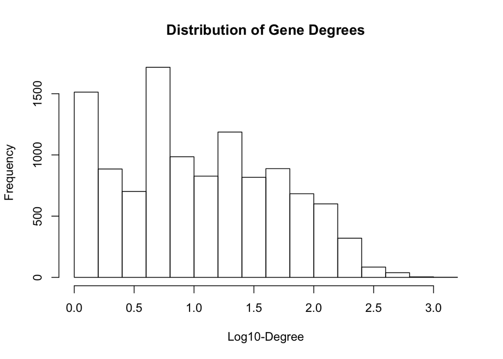

```r
# analyze distribution of the degree of genes
geneDegrees <- degree(fi_graph)
logGeneDegrees <- log10(geneDegrees) # calculate log10-degree of genes
hist(logGeneDegrees,
     main = "Distribution of Gene Degrees",
     xlab = "Log10-Degree",
     ylab = "Frequency") # make histogram of degrees
```

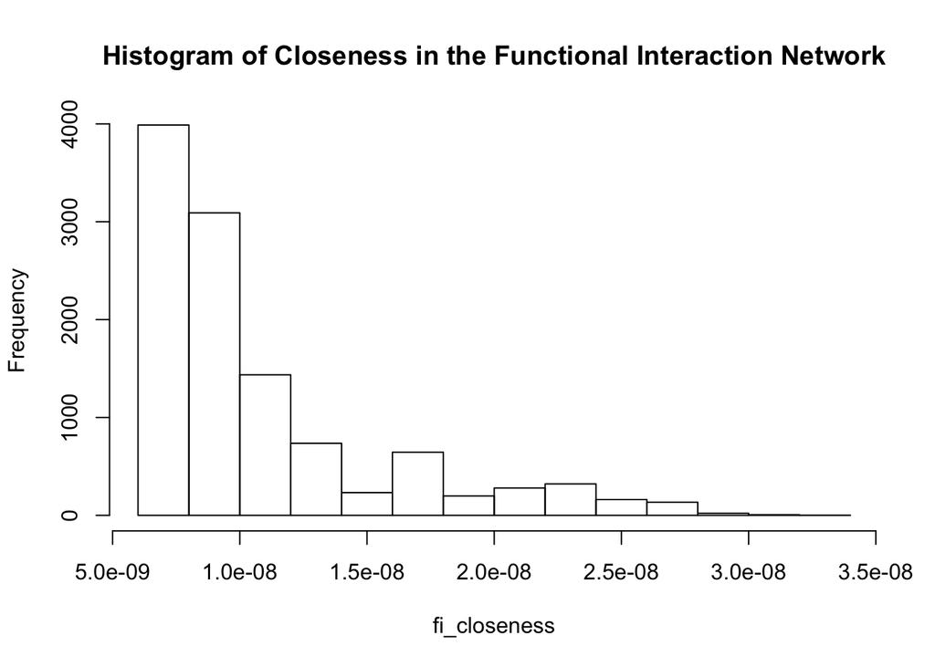

```r
# analyze closeness of genes
fi_closeness <- closeness(fi_graph)
hist(x = fi_closeness,
     main = "Histogram of Closeness in the Functional Interaction Network")
```

## Degree Centrality of Genes in Fusions

```r
# focus on genes in fusions
fusionDegrees <- geneDegrees[allUniqueGenes] # get only fusion degrees
length(fusionDegrees) # number of fusion genes
```

```
## [1] 247
```

```r
fusionDegrees <- fusionDegrees[!is.na(fusionDegrees)] # remove NA values
length(fusionDegrees) # number of fusion genes after filtering
```

```
## [1] 199
```

```r
fusionsInFI <- names(fusionDegrees) # get genes in FI network

# focus on non-Fusion genes
otherGeneDegrees <- geneDegrees[setdiff(names(geneDegrees), allUniqueGenes)]
length(otherGeneDegrees)
```

```
## [1] 11051
```

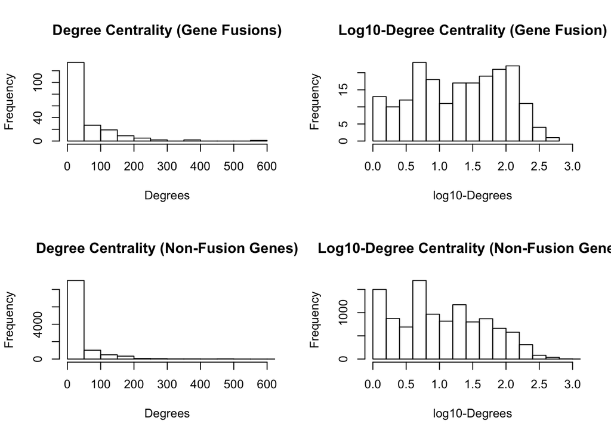

```r
# plot histograms of degree centralities of fusion genes and non-fusion genes
par(mfrow = c(2,2))
hist(x = fusionDegrees,
     main = "Degree Centrality (Gene Fusions)",
     xlab = "Degrees",
     xlim =  c(0,600))
hist(x = log10(fusionDegrees),
     main = "Log10-Degree Centrality (Gene Fusion)",
     xlab = "log10-Degrees",
     xlim =  c(0,3),
     breaks = 10)
hist(x = otherGeneDegrees,
     main = "Degree Centrality (Non-Fusion Genes)",
     xlab = "Degrees",
     xlim = c(0,600))
hist(x = log10(otherGeneDegrees),
     main = "Log10-Degree Centrality (Non-Fusion Genes)",
     xlab = "log10-Degrees",
     xlim = c(0,3),
     breaks = 20)
```

## Closeness Centrality of Genes in Fusions

```r
geneCloseness <- closeness(graph = fi_graph) # all genes in analysis
head(geneCloseness)
```

```
##                16-5-5 <DELTA>FAS/APO-1/CD95                  A1CF
##          9.769266e-09          2.505580e-08          1.756665e-08
##                   A2M                  AAAS                 AADAT
##          2.941863e-08          2.339030e-08          2.782898e-08
```

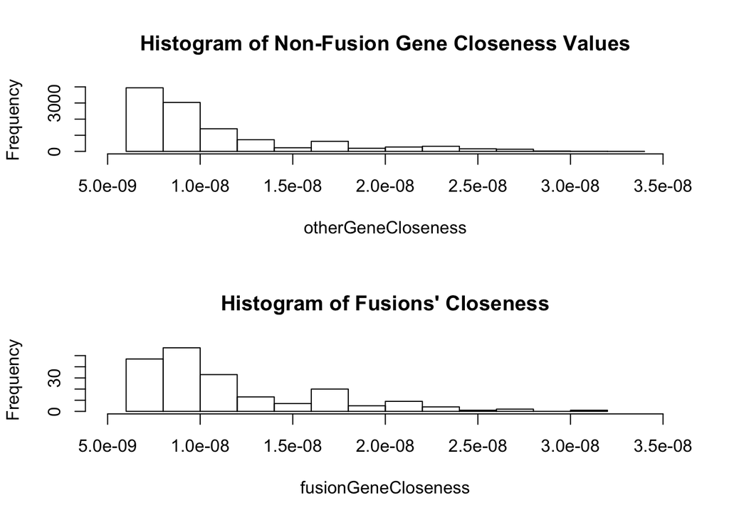

```r
otherGeneCloseness <- geneCloseness[setdiff(names(geneCloseness),
                                            allUniqueGenes)]

# put two histograms on one plot
par(mfrow = c(2,1))

# plot analysis for non-fusion genes
hist(x = otherGeneCloseness,
     main = "Histogram of Non-Fusion Gene Closeness Values",
     xlim = c(5.0e-09, 3.5e-08))

# plot analysis for fusion genes
fusionGeneCloseness <- closeness(graph = fi_graph, vids = fusionsInFI)
hist(x = fusionGeneCloseness,
     main = "Histogram of Fusions' Closeness",
     xlim = c(5.0e-09, 3.5e-08))
```

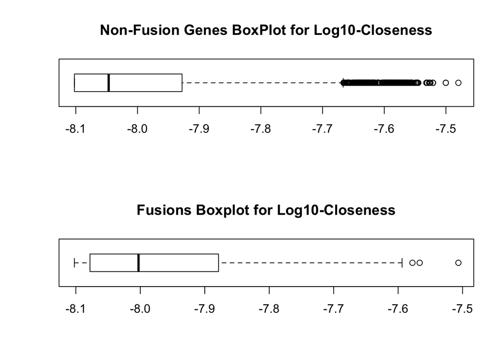

```r
# put two boxplots on one plot
par(mfrow = c(2,1))
boxplot(x = log10(otherGeneCloseness), horizontal = TRUE)
title(main = "Non-Fusion Genes BoxPlot for Log10-Closeness")
boxplot(x = log10(fusionGeneCloseness), horizontal = TRUE)
title(main = "Fusions Boxplot for Log10-Closeness")
```

## Betweenness Centrality of Genes in Fusions

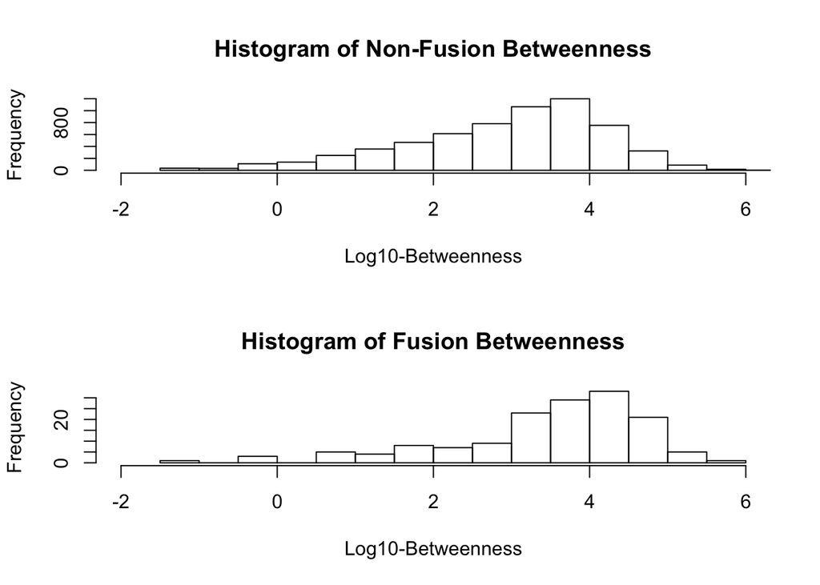

```r
# calculate betweenness values for fusions and all genes
geneBetween <- betweenness(graph = fi_graph)
otherGeneBetween <- geneBetween[setdiff(names(geneBetween),
                                        allUniqueGenes)]
fusionBetween <- betweenness(graph = fi_graph, v = fusionsInFI)

# put two plots in one
par(mfrow = c(2,1))

# all other genes
hist(log10(otherGeneBetween),
     breaks = 15,
     main = "Histogram of Non-Fusion Betweenness",
     xlab = "Log10-Betweenness",
     xlim = c(-2,6))
# genes in fusions
hist(log10(fusionBetween),
     breaks = 15,
     main = "Histogram of Fusion Betweenness",
     xlab = "Log10-Betweenness",
     xlim = c(-2,6))
```

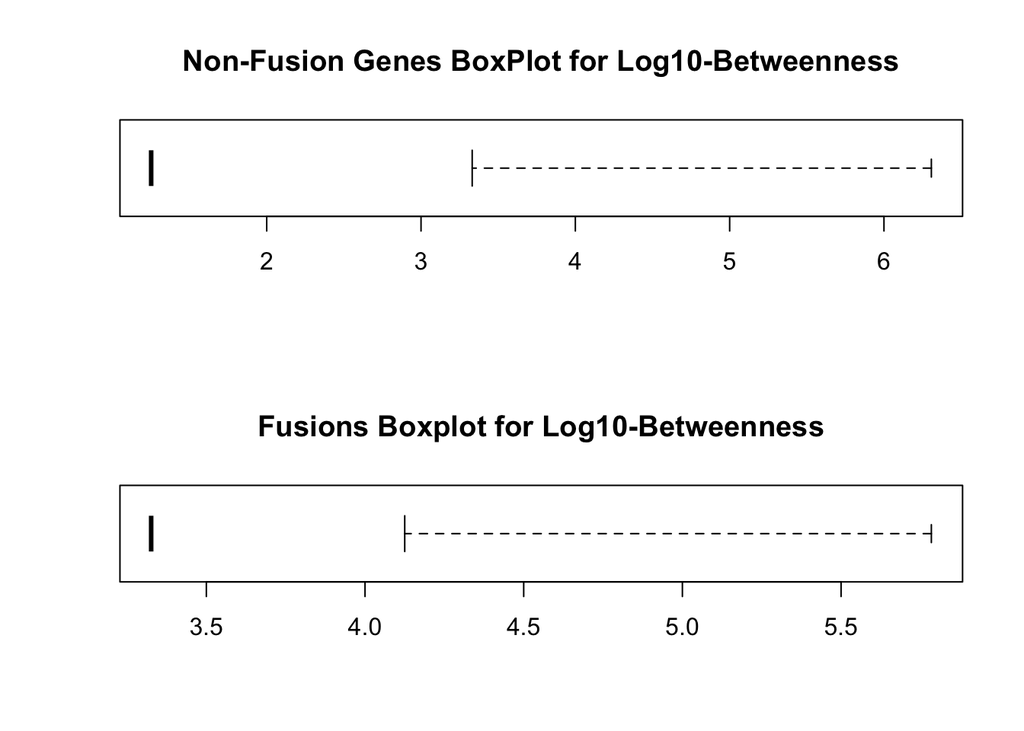

```r
# put two boxplots on one plot
par(mfrow = c(2,1))
boxplot(x = log10(otherGeneBetween), horizontal = TRUE)
title(main = "Non-Fusion Genes BoxPlot for Log10-Betweenness")
boxplot(x = log10(fusionBetween), horizontal = TRUE)
title(main = "Fusions Boxplot for Log10-Betweenness")
```

```r
ks.test(log10(fusionBetween), log10(otherGeneBetween))
```

```
##
##  Two-sample Kolmogorov-Smirnov test
##
## data:  log10(fusionBetween) and log10(otherGeneBetween)
## D = 0.26555, p-value = 2.128e-12
## alternative hypothesis: two-sided
```

```r
x <- rnorm(15)
ks.test(x, y = rnorm)
```

[output not shown]